# Estimadores de James-Stein

# Regresión Ridge

Consideramos el modelo Bayesiano

\begin{align*} \\ \pmb{\beta} &\sim \text{Normal}\left(\pmb{0}, \frac{1}{2 \tau^2}\pmb{I}_p \right) \\ \pmb{y}\,|\,\pmb{\beta},\hat{\pmb{X}} \,&\sim \text{Normal}\left(\hat{\pmb{X}}\pmb{\beta},\sigma^2\pmb{I}_n\right) \end{align*}

con $\tau^2,\sigma^2>0.$

Entonces

$$ p(\pmb{\beta}|\pmb{D})\propto \exp\left( - \frac{1}{2\sigma^2}\sum_{i=1}^n \left(y_i-\pmb{X}_i'\pmb{\beta} \right)^2 \right) \exp\left( - \tau^2 \sum_{j=0}^p \beta_j^2 \right) $$

El estimador máximo a posteriori está dado por

\begin{align*} \hat{\pmb{\beta}}^{(\text{MAXPOST})} &= \underset{\pmb{\beta}}{\arg \max} \;p(\pmb{\beta}|\pmb{D}) \\ & = \underset{\pmb{\beta}}{\arg \min} \left[ \left( \sum_{i=1}^n \left(y_i-\pmb{X}_i'\pmb{\beta} \right)^2 \right) + \lambda \sum_{j=0}^p \beta_j^2 \right] \\ & = \underset{\pmb{\beta}}{\arg \min} \left( \left\| \pmb{y}-\hat{\pmb{X}}\pmb{\beta} \right \|_2^2 + \lambda \left\| \pmb{\beta} \right\|_2^2 \right) \end{align*}

con $\lambda= \left(\frac{\sigma}{\tau}\right)^2$.

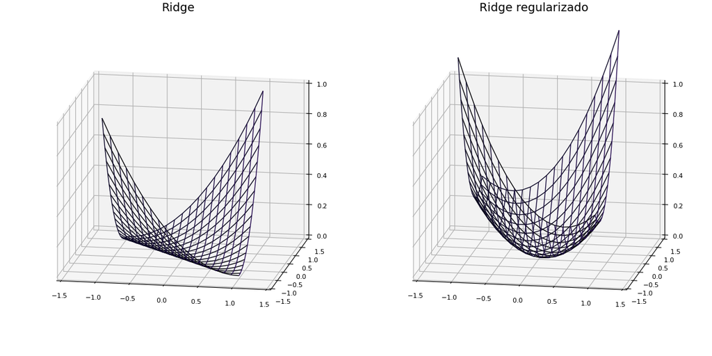

```julia
plt
```

El estimador máximo a posteriori está dado por

$$ \hat{\pmb{\beta}}^{(\text{MAP})} = \left( \pmb{X}'\pmb{X} + \lambda\pmb{I}_p \right)^{-1}\pmb{X}'\pmb{y}, \quad \hat{\beta}^{(\text{MAP})}_0 = \bar{y}. $$

Para calcular numéricamente el estimador $\hat{\pmb{\beta}}^{(\text{MAP})}$ consideramos

$$ \tilde{\pmb{X}} = \left( \begin{matrix} \frac{1}{\sigma}\pmb{X} \\ \frac{1}{\tau}\pmb{I}_p \end{matrix}\right) ,\quad \tilde{\pmb{y}} = \left( \begin{matrix} \frac{1}{\sigma}\pmb{y} \\ \pmb{0}_{p\times 1} \end{matrix}\right) $$

con lo cual obtenemos un problema de mínimos cuadrados que puede ser calculado haciendo uso de la descomposición QR

\begin{align*} \left( \tilde{\pmb{y}}-\tilde{\pmb{X}}\pmb{\beta} \right)'\left( \tilde{\pmb{y}}-\tilde{\pmb{X}}\pmb{\beta} \right) & = \left( \left( \begin{matrix} \frac{1}{\sigma}\pmb{y} \\ \pmb{0}_{p\times 1} \end{matrix}\right) - \left( \begin{matrix} \frac{1}{\sigma}\pmb{X} \\ \frac{1}{\tau}\pmb{I}_p \end{matrix}\right) \pmb{\beta} \right)'\left( \left( \begin{matrix} \frac{1}{\sigma}\pmb{y} \\ \pmb{0}_{p\times 1} \end{matrix}\right) - \left( \left( \begin{matrix} \frac{1}{\sigma}\pmb{X} \\ \frac{1}{\tau}\pmb{I}_p \end{matrix}\right) \pmb{\beta} \right) \right) \\ & = \left( \begin{matrix} \frac{1}{\sigma}\left( \pmb{y} - \pmb{X}\pmb{\beta} \right) \\ -\frac{1}{\tau}\pmb{\beta} \end{matrix}\right)'\left( \begin{matrix} \frac{1}{\sigma}\left( \pmb{y} - \pmb{X}\pmb{\beta} \right) \\ -\frac{1}{\tau}\pmb{\beta} \end{matrix}\right) = \frac{1}{\sigma^2}\left( \pmb{y} - \pmb{X}\pmb{\beta} \right)'\left( \pmb{y} - \pmb{X}\pmb{\beta} \right) + \frac{1}{\tau^2}\pmb{\beta}'\pmb{\beta} \end{align*}

Por lo que altternativamente se puede calcular

$$ \hat{\pmb{\beta}}^{(\text{MAP})} = \left( \tilde{\pmb{X}}'\tilde{\pmb{X}} \right)^{-1}\tilde{\pmb{X}}'\tilde{\pmb{y}} $$

## Ejemplo regresión polinomial para función trigonométrica

En la regresión polinomial, dados covariables $\pmb{X}$ consideramos monomios asociados como covariables extra. En el ejemplo más sencillo tenemos un único covariable $x$ que extendemos a $\pmb{X}=(x,x^2,x^3,\ldots,x^p)$ donde $p$ es llamado el grado de la regresión polinomial. Por ejemplo si observamos la función $y(x)=\sin(x)$ ruidosamente en $n$ puntos $x_1,\ldots, x_n$ con $\left\{\epsilon_i \right\}_{i=1}^n\stackrel{\text{i.i.d.}}{\sim}\text{Normal}(0,\sigma^2)$

$$ y_i = \sin(x_i) + \epsilon_i \approx \hat{y}_i = \beta_0 + \beta_1 x_i + \beta_2 x_i^2 + \ldots+ \beta_p x_i^p. $$

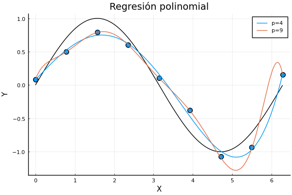

```julia
plt
```

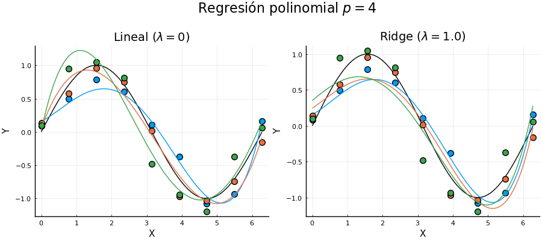

```julia
plt4_c
```

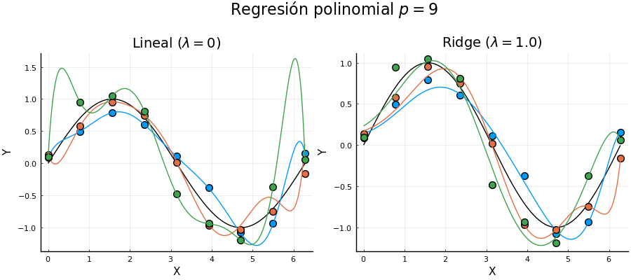

```julia
plt9_c
```

En este caso el riesgo, o error cuadrático medio, está dado por

\begin{align*} &\mathbb{E}\left[ \,\left\| \hat{f} - f \right\|_2^2\, \right] = \mathbb{E}\left[ \int \left( \hat{f}(x)-f(x) \right)^2 \mathrm{d}x \right]= \mathbb{E}\left[ \int \left( \hat{f}(x) - \mathbb{E}\left[ \hat{f}(x) \right] + \mathbb{E}\left[ \hat{f}(x) \right] - f(x) \right)^2 \mathrm{d}x \right] \\&= \mathbb{E}\left[ \int \left( \hat{f}(x) - \mathbb{E}\left[ \hat{f}(x) \right] \right)^2 \mathrm{d}x \right] + 2\mathbb{E}\left[ \int \left( \hat{f}(x) - \mathbb{E}\left[ \hat{f}(x) \right] \right)\left( \mathbb{E}\left[ \hat{f}(x) \right]- f(x) \right) \mathrm{d}x \right]+ \mathbb{E}\left[ \int\left( \mathbb{E}\left[ \hat{f}(x) \right]-f(x) \right)^2 \mathrm{d}x \right] \\ &= \int \text{Var}\left( \hat{f}(x) \right)\mathrm{d}x + \int \left( \mathbb{E}\left[ \hat{f}(x) \right] - f(x) \right)^2 = \int \left( \text{Var}\left( \hat{f}(x) \right) + \text{Sesgo}(\hat{f}(x) ,f(x))^2 \right)\mathrm{d}x \end{align*}

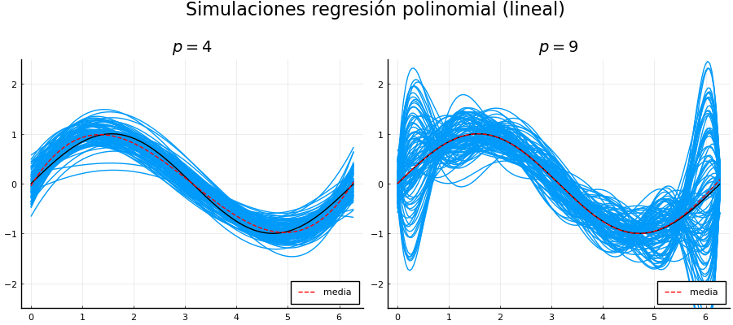

```julia
plt_mc
```

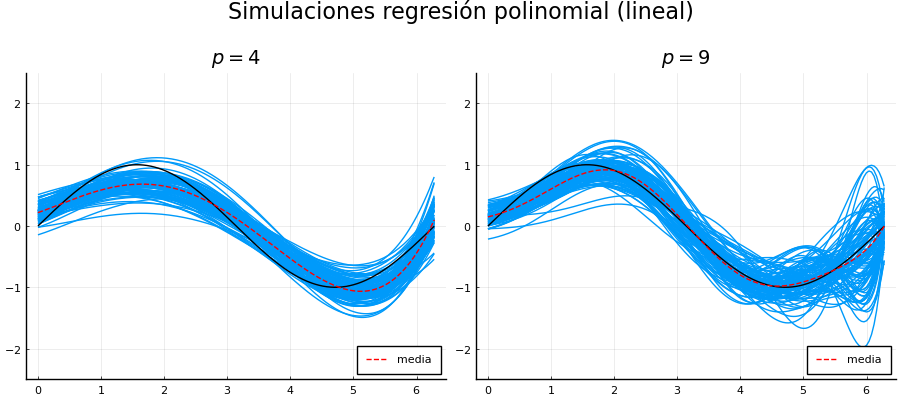

```julia
pltr_mc
```

```julia
# Estimación varianza integrada reg-pol p=4 con Monte-Carlo e integración con regla trapezoidal
v = trapz(collect(t_mc),var(M_4,dims=1)[1,:])
```

```
0.18100404397570352
```

```julia
# Estimación varianza reg-pol-ridge p=4 con Monte-Carlo e integración con regla trapezoidal
vr = trapz(collect(t_mc),var(M_4_r,dims=1)[1,:])
```

```
0.12187991310774075
```

```julia
# Estimación sesgo-cuadrado integrado reg-pol p=4 con Monte-Carlo e integración con regla trapezoidal
s = trapz(collect(t_mc),(mean(M_4,dims=1)[1,:] .- sin.(t_mc)).^2)
```

```
0.04350716880894909
```

```julia
# Estimación sesgo-cuadrado integrado reg-pol ridge p=4 con Monte-Carlo e integración con regla trapezoidal
sr = trapz(collect(t_mc),(mean(M_4_r,dims=1)[1,:] .- sin.(t_mc)).^2)
```

```
0.2379008461073797
```

```julia
# Riesgos estimados p=4
v+s, vr+sr
```

```
(0.2245112127846526, 0.3597807592151204)
```

```julia
# Estimación varianza integrada reg-pol p=9 con Monte-Carlo e integración con regla trapezoidal
v = trapz(collect(t_mc),var(M_9,dims=1)[1,:])
```

```
1.4159254759188304
```

```julia
# Estimación varianza reg-pol-ridge p=9 con Monte-Carlo e integración con regla trapezoidal
vr = trapz(collect(t_mc),var(M_9_r,dims=1)[1,:])
```

```
0.37554056693080584
```

```julia
# Estimación sesgo-cuadrado integrado reg-pol p=9 con Monte-Carlo e integración con regla trapezoidal
s = trapz(collect(t_mc),(mean(M_9,dims=1)[1,:] .- sin.(t_mc)).^2)
```

```
0.002191452851261467
```

```julia
# Estimación sesgo-cuadrado integrado reg-pol ridge p=9 con Monte-Carlo e integración con regla trapezoidal
sr = trapz(collect(t_mc),(mean(M_9_r,dims=1)[1,:] .- sin.(t_mc)).^2)
```

```
0.060640800027199224
```

```julia
# Riesgos estimados p=9
v+s, vr+sr
```

```
(1.4181169287700919, 0.4361813669580051)
```

### Ejemplo datos inmobiliarios

```julia
# Datos casas de Boston
boston_df = DataFrame(boston["data"], PyCall.py2array(String,boston["feature_names"]))
```

506×13 DataFrame

481 rows omitted

| Row | CRIM Float64 | ZN Float64 | INDUS Float64 | CHAS Float64 | NOX Float64 | RM Float64 | AGE Float64 | DIS Float64 | RAD Float64 | TAX Float64 | PTRATIO Float64 | B Float64 | LSTAT Float64 |
| --- | --- | --- | --- | --- | --- | --- | --- | --- | --- | --- | --- | --- | --- |
| 1 | 0.00632 | 18.0 | 2.31 | 0.0 | 0.538 | 6.575 | 65.2 | 4.09 | 1.0 | 296.0 | 15.3 | 396.9 | 4.98 |
| 2 | 0.02731 | 0.0 | 7.07 | 0.0 | 0.469 | 6.421 | 78.9 | 4.9671 | 2.0 | 242.0 | 17.8 | 396.9 | 9.14 |
| 3 | 0.02729 | 0.0 | 7.07 | 0.0 | 0.469 | 7.185 | 61.1 | 4.9671 | 2.0 | 242.0 | 17.8 | 392.83 | 4.03 |
| 4 | 0.03237 | 0.0 | 2.18 | 0.0 | 0.458 | 6.998 | 45.8 | 6.0622 | 3.0 | 222.0 | 18.7 | 394.63 | 2.94 |
| 5 | 0.06905 | 0.0 | 2.18 | 0.0 | 0.458 | 7.147 | 54.2 | 6.0622 | 3.0 | 222.0 | 18.7 | 396.9 | 5.33 |
| 6 | 0.02985 | 0.0 | 2.18 | 0.0 | 0.458 | 6.43 | 58.7 | 6.0622 | 3.0 | 222.0 | 18.7 | 394.12 | 5.21 |
| 7 | 0.08829 | 12.5 | 7.87 | 0.0 | 0.524 | 6.012 | 66.6 | 5.5605 | 5.0 | 311.0 | 15.2 | 395.6 | 12.43 |
| 8 | 0.14455 | 12.5 | 7.87 | 0.0 | 0.524 | 6.172 | 96.1 | 5.9505 | 5.0 | 311.0 | 15.2 | 396.9 | 19.15 |
| 9 | 0.21124 | 12.5 | 7.87 | 0.0 | 0.524 | 5.631 | 100.0 | 6.0821 | 5.0 | 311.0 | 15.2 | 386.63 | 29.93 |
| 10 | 0.17004 | 12.5 | 7.87 | 0.0 | 0.524 | 6.004 | 85.9 | 6.5921 | 5.0 | 311.0 | 15.2 | 386.71 | 17.1 |
| 11 | 0.22489 | 12.5 | 7.87 | 0.0 | 0.524 | 6.377 | 94.3 | 6.3467 | 5.0 | 311.0 | 15.2 | 392.52 | 20.45 |
| 12 | 0.11747 | 12.5 | 7.87 | 0.0 | 0.524 | 6.009 | 82.9 | 6.2267 | 5.0 | 311.0 | 15.2 | 396.9 | 13.27 |
| 13 | 0.09378 | 12.5 | 7.87 | 0.0 | 0.524 | 5.889 | 39.0 | 5.4509 | 5.0 | 311.0 | 15.2 | 390.5 | 15.71 |
| ⋮ | ⋮ | ⋮ | ⋮ | ⋮ | ⋮ | ⋮ | ⋮ | ⋮ | ⋮ | ⋮ | ⋮ | ⋮ | ⋮ |
| 495 | 0.27957 | 0.0 | 9.69 | 0.0 | 0.585 | 5.926 | 42.6 | 2.3817 | 6.0 | 391.0 | 19.2 | 396.9 | 13.59 |
| 496 | 0.17899 | 0.0 | 9.69 | 0.0 | 0.585 | 5.67 | 28.8 | 2.7986 | 6.0 | 391.0 | 19.2 | 393.29 | 17.6 |
| 497 | 0.2896 | 0.0 | 9.69 | 0.0 | 0.585 | 5.39 | 72.9 | 2.7986 | 6.0 | 391.0 | 19.2 | 396.9 | 21.14 |
| 498 | 0.26838 | 0.0 | 9.69 | 0.0 | 0.585 | 5.794 | 70.6 | 2.8927 | 6.0 | 391.0 | 19.2 | 396.9 | 14.1 |
| 499 | 0.23912 | 0.0 | 9.69 | 0.0 | 0.585 | 6.019 | 65.3 | 2.4091 | 6.0 | 391.0 | 19.2 | 396.9 | 12.92 |
| 500 | 0.17783 | 0.0 | 9.69 | 0.0 | 0.585 | 5.569 | 73.5 | 2.3999 | 6.0 | 391.0 | 19.2 | 395.77 | 15.1 |
| 501 | 0.22438 | 0.0 | 9.69 | 0.0 | 0.585 | 6.027 | 79.7 | 2.4982 | 6.0 | 391.0 | 19.2 | 396.9 | 14.33 |
| 502 | 0.06263 | 0.0 | 11.93 | 0.0 | 0.573 | 6.593 | 69.1 | 2.4786 | 1.0 | 273.0 | 21.0 | 391.99 | 9.67 |
| 503 | 0.04527 | 0.0 | 11.93 | 0.0 | 0.573 | 6.12 | 76.7 | 2.2875 | 1.0 | 273.0 | 21.0 | 396.9 | 9.08 |
| 504 | 0.06076 | 0.0 | 11.93 | 0.0 | 0.573 | 6.976 | 91.0 | 2.1675 | 1.0 | 273.0 | 21.0 | 396.9 | 5.64 |
| 505 | 0.10959 | 0.0 | 11.93 | 0.0 | 0.573 | 6.794 | 89.3 | 2.3889 | 1.0 | 273.0 | 21.0 | 393.45 | 6.48 |
| 506 | 0.04741 | 0.0 | 11.93 | 0.0 | 0.573 | 6.03 | 80.8 | 2.505 | 1.0 | 273.0 | 21.0 | 396.9 | 7.88 |

```julia
print(boston["DESCR"])
```

```
Boston House Prices dataset
===========================

Notes
------
Data Set Characteristics:

    :Number of Instances: 506

    :Number of Attributes: 13 numeric/categorical predictive

    :Median Value (attribute 14) is usually the target

    :Attribute Information (in order):
        - CRIM     per capita crime rate by town
        - ZN       proportion of residential land zoned for lots over 25,000 sq.ft.
        - INDUS    proportion of non-retail business acres per town
        - CHAS     Charles River dummy variable (= 1 if tract bounds river; 0 otherwise)
        - NOX      nitric oxides concentration (parts per 10 million)
        - RM       average number of rooms per dwelling
        - AGE      proportion of owner-occupied units built prior to 1940
        - DIS      weighted distances to five Boston employment centres
        - RAD      index of accessibility to radial highways
        - TAX      full-value property-tax rate per $10,000
        - PTRATIO  pupil-teacher ratio by town
        - B        1000(Bk - 0.63)^2 where Bk is the proportion of blacks by town
        - LSTAT    % lower status of the population
        - MEDV     Median value of owner-occupied homes in $1000's

    :Missing Attribute Values: None

    :Creator: Harrison, D. and Rubinfeld, D.L.

This is a copy of UCI ML housing dataset.
http://archive.ics.uci.edu/ml/datasets/Housing


This dataset was taken from the StatLib library which is maintained at Carnegie Mellon University.

The Boston house-price data of Harrison, D. and Rubinfeld, D.L. 'Hedonic
prices and the demand for clean air', J. Environ. Economics & Management,
vol.5, 81-102, 1978.   Used in Belsley, Kuh & Welsch, 'Regression diagnostics
...', Wiley, 1980.   N.B. Various transformations are used in the table on
pages 244-261 of the latter.

The Boston house-price data has been used in many machine learning papers that address regression
problems.

**References**

   - Belsley, Kuh & Welsch, 'Regression diagnostics: Identifying Influential Data and Sources of Collinearity', Wiley, 1980. 244-261.
   - Quinlan,R. (1993). Combining Instance-Based and Model-Based Learning. In Proceedings on the Tenth International Conference of Machine Learning, 236-243, University of Massachusetts, Amherst. Morgan Kaufmann.
   - many more! (see http://archive.ics.uci.edu/ml/datasets/Housing)
```

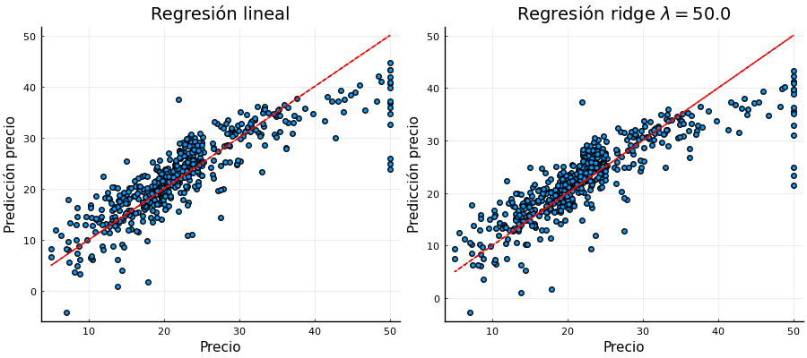

```julia
plt
```

```julia
# Error de predicción modelo lineal
mean( (y .- y_pred_linreg ).^2 )
```

```
21.8977792176875
```

```julia
# Error de predicción modelo cresta
mean( (y .- y_pred_ridge ).^2 )
```

```
22.653952885588446
```

```julia
# Differencia
mean( (y_pred_linreg .- y_pred_ridge ).^2 )
```

```
0.7561736679009757
```

```julia
# scikit-learn en python
py"""
from sklearn.linear_model import Ridge
model = Ridge(50.0)
fit_py = model.fit($(X), $(y))
"""
```